# Discussion 9

Dmitriy Izyumin

March 4, 2017

# Spectral Density

The idea that a time series is composed of periodic components, appearing in proportion to their underlying variances, is fundamental in the spectral representation. The result, called the Spectral Representation Theorem, serves as a connection between the spectral density and the autocovariance functions.

## Spectral Representation Theorem

If the autocovariance function, $\gamma(h)$, of a stationary process satisfies
$$\sum_{j=1}^\infty|\gamma(h)|<\infty, \qquad\text{i.e., absolutely summable}$$
then it has the representation
$$\gamma(h)=\int_{-1/2}^{1/2}e^{2\pi i \omega h}f(\omega)d\omega, \qquad h=0,\pm 1, \pm 2, \dots.$$
On the other hand the spectral density has the representation
$$f(\omega)=\sum_{h=-\infty}^{\infty}\gamma(h)e^{-2\pi i \omega h}, \qquad -1/2\leq \omega \leq 1/2.$$

## White noise:

To find the power spectral density of white noise $\varepsilon_t\sim(0,\sigma^2_\varepsilon)$, one needs to find the autocovariance function first. Recall the autocovariance function of white noise is $\gamma(h)=\sigma^2_\varepsilon$ if $h=0$ and $\gamma(h)=0$ if $h\neq 0$. Then the power spectrum (spectral density) is:
$$f_\varepsilon(\omega) = \sum_{h=-\infty}^{\infty}\gamma(h)e^{-2\pi i \omega h} = \gamma(0)e^{-2\pi i \omega(0)}=\gamma(0)=\sigma^2_\varepsilon.$$

## MA(1) process

Consider the MA(1) process:
$$X_t = \varepsilon_t + \theta \varepsilon_{t-1},$$
where $\theta$ is a parameter.

### Part a

In order to derive a formula for the spectral density of $X_t$, expressed in terms of $\theta$ and $\omega$, we first need to recall the autocovariance function of MA(1) process $X_t$, i.e.,

$$\gamma_X(h)=\begin{cases}
(1+\theta^2)\sigma^2 & h= 0 \\
\theta\sigma^2 & |h|=1 \\
0 & |h|>1
\end{cases}, \qquad \text{VERIFY THIS!}$$

Then the spectral density of $X_t$ is given by:

$$\begin{align*}
f_X(\omega) &= \sum_{h=-\infty}^{\infty}\gamma_x(h)e^{-2\pi i \omega h} \\
& = \gamma_x(-1)e^{2\pi i\omega}+\gamma_x(0)+\gamma_x(1)e^{-2\pi i \omega} \\
& = \theta\sigma^2\underbrace{[e^{2\pi i\omega}+e^{-2\pi i\omega}]}_{2\cos(2\pi \omega)}+(1+\theta^2)\sigma^2\\
& = \sigma^2[1+2\theta\cos(2\pi \omega)+\theta^2]
\end{align*}$$

Note that the above identity comes from the property:
$$e^{i\alpha} = \cos(\alpha)+i\sin(\alpha).$$
In above equation we have

$$\begin{align*}
[e^{2\pi i \omega}+e^{-2\pi i \omega}] &= \cos(2\pi \omega) + i\sin(2\pi \omega)+ \cos(-2\pi \omega) + i\sin(-2\pi \omega) \\
& = \cos(2\pi \omega) + i\sin(2\pi \omega)+ \cos(2\pi \omega) - i\sin(2\pi \omega) \\
& = 2\cos(2\pi \omega)
\end{align*}$$

### Part b

Assuming $\theta=0.5$

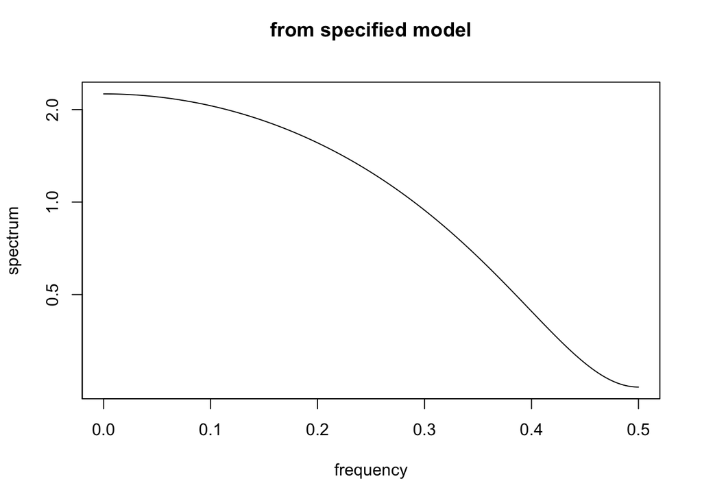

```r
library(astsa)
arma.spec(ma=0.5)
```

and also assuming $\theta=-0.5$

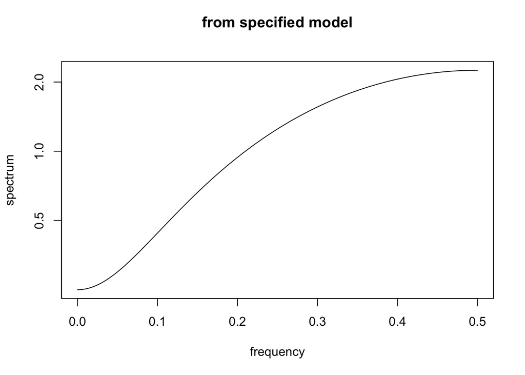

```r
library(astsa)
arma.spec(ma=-0.5)
```

### Part c

when $\theta>0$ (the first plot), it seems that the low frequencies have a larger spectrum, whereas when $\theta<0$ (second plot), it is reversed and the high frequencies have a larger spectrum.

## The Spectral Density of ARMA (Property 4.2)

If $X_t$ has an ARMA($p,q$), with $\phi(B)X_t = \theta(B)\varepsilon_t$, its spectral density is given by
$$f_X(\omega)=\sigma^2_\varepsilon|\psi(e^{-2\pi i \omega})|^2 = \frac{|\theta(e^{-2\pi i \omega})|^2}{|\phi(e^{-2\pi i \omega})|^2}\sigma^2_\varepsilon.$$
where $\phi(z)=1-\sum_{j=1}^p\phi_kz^j$, and $\theta(z)=1+\sum_{j=1}^q\theta_kz^j$, and $\psi(z)=\sum_{k=0}^\infty\psi_kz^k$.

## AR(1) process

Consider a first-order autoregressive model
$$X_t = \phi X_{t-1}+\varepsilon_t$$
where $\phi$, for $|\phi|<1$, is a parameter and the $\varepsilon_t$ are independent random variables with mean zero and variance $\sigma^2_\varepsilon$.

Here we will derive the spectral density function for $X_t$ by using the above property. Note that the AR polynomial of AR(1) is $\phi(z)=1-\phi z$, and the MA polynomial is just $\theta(z)=1$ (since we have only AR process). We have

$$\begin{align*}
f_X(\omega) &= \frac{1}{|\phi(e^{-2\pi i \omega})|^2}\sigma^2_\varepsilon
\end{align*}$$
Note that for any complex number $z=a+ib$, we have the identity
$$|z|^2=(a+ib)(a-ib)=a^2+b^2.$$
Hence we have
$$\begin{align*}
|\phi(e^{-2\pi i \omega})|^2 &= |1-\phi e^{-2\pi i \omega}|^2 \\
&= (1-\phi e^{-2\pi i \omega})(1-\phi e^{2\pi i \omega}) \\
&= 1 - \phi\underbrace{(e^{-2\pi i \omega}+e^{2\pi i \omega})}_{2\cos(2\pi \omega)} + \phi^2 \\
&= 1-2\phi\cos(2\pi \omega)+\phi^2,
\end{align*}$$

and the spectral density is
$$f_X(\omega) = \frac{\sigma^2_\omega}{1-2\phi\cos(2\pi \omega)+\phi^2}.$$

## From Last Time

### Part a

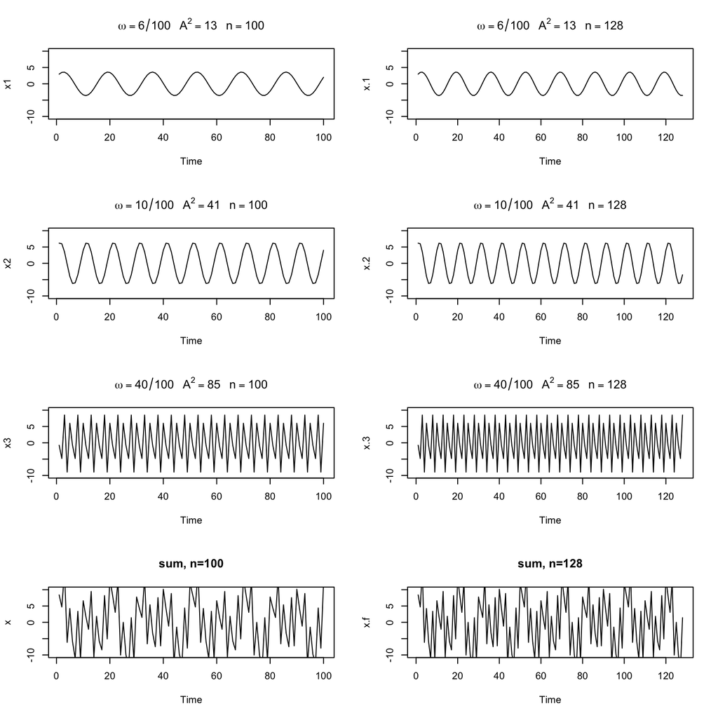

```r
t = 1:100
x1 = 2*cos(2*pi*t*6/100) + 3*sin(2*pi*t*6/100)
x2 = 4*cos(2*pi*t*10/100) + 5*sin(2*pi*t*10/100)
x3 = 6*cos(2*pi*t*40/100) + 7*sin(2*pi*t*40/100)
x =x1+x2+x3

t = 1:128
x.1 = 2*cos(2*pi*t*6/100) + 3*sin(2*pi*t*6/100)
x.2 = 4*cos(2*pi*t*10/100) + 5*sin(2*pi*t*10/100)
x.3 = 6*cos(2*pi*t*40/100) + 7*sin(2*pi*t*40/100)
x.f =x.1+x.2+x.3

par(mfrow=c(4,2))
plot.ts(x1, ylim=c(-10,10), main=expression(omega==6/100~~~A^2==13~~~n==100))
plot.ts(x.1, ylim=c(-10,10), main=expression(omega==6/100~~~A^2==13~~~n==128))
plot.ts(x2, ylim=c(-10,10), main=expression(omega==10/100~~~A^2==41~~~n==100))
plot.ts(x.2, ylim=c(-10,10), main=expression(omega==10/100~~~A^2==41~~~n==128))
plot.ts(x3, ylim=c(-10,10), main=expression(omega==40/100~~~A^2==85~~~n==100))
plot.ts(x.3, ylim=c(-10,10), main=expression(omega==40/100~~~A^2==85~~~n==128))
plot.ts(x, ylim=c(-10,10), main="sum, n=100")
plot.ts(x.f, ylim=c(-10,10), main="sum, n=128")
```

Note that the difference is the fundamental frequencies, i.e., $w_j=j/n$ where $j$ is the cycles and $n$ is the sample size. For the first process when $n=100$, the fundamental frequency is $6/100$ since there are total of $6$ cycles, where as when $n=128$, we have roughly $j=7.5$ cyles which gives $7.5/100=0.058$ as a fundamental frequency. This applies to all four peocesses above.

### Part b

To plot the periodogram, one can either follow the steps from previous discussion using the fast Fourier transform, or simply use the R function $spec.pgram()$

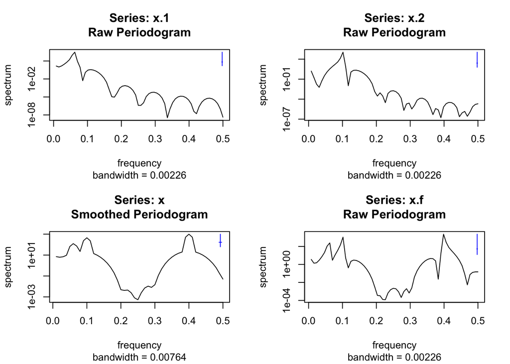

```r
par(mfrow=c(2,2))
spec.pgram(x.1)
spec.pgram(x.2)
spec.pgram(x,3)
spec.pgram(x.f)
```

### Part c

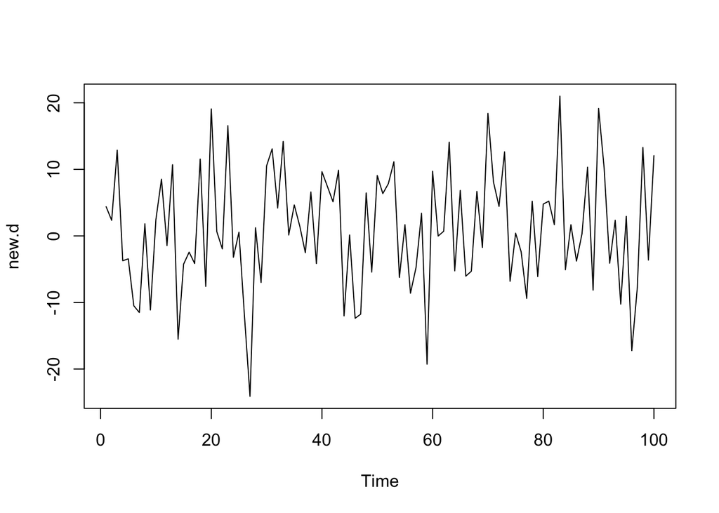

```r
new.d = x + rnorm(100,0,5)
plot.ts(new.d)
```

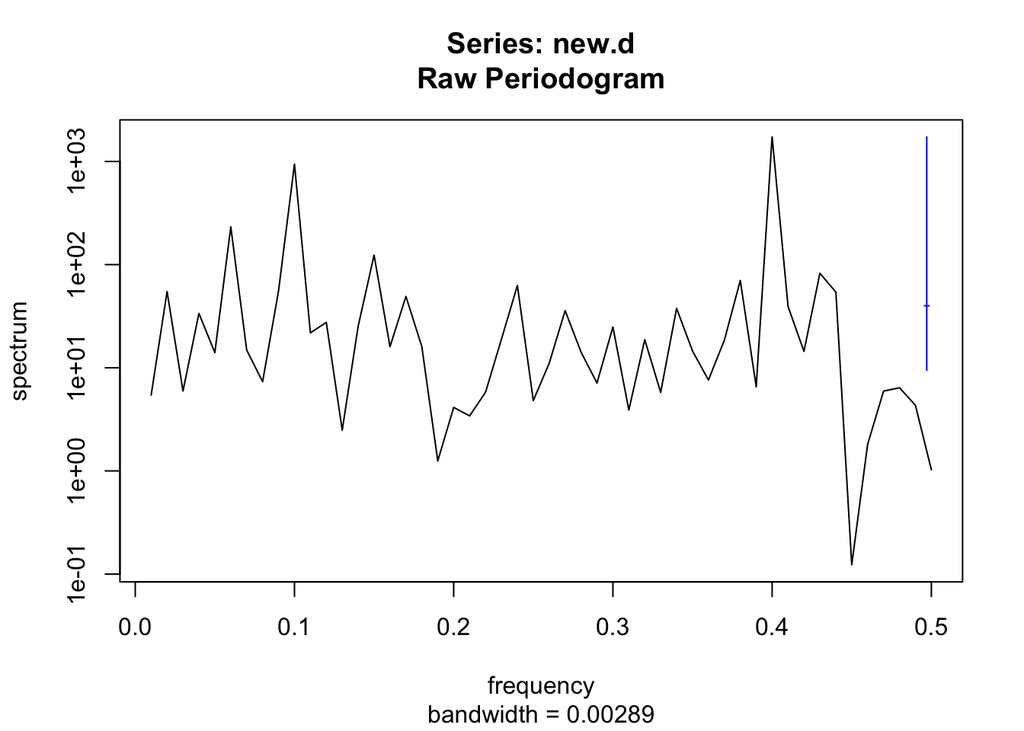

```r
spec.pgram(new.d)
```

The periodogram of the new data has the similar dominant frequencies as the the non-noisy data, and adding the white noise seems not to affect the dominant frequency.

### Smoothing

The same function can also compute periodogram values smoothed with the Daniell kernel. The argument `spans` has to be an odd number, and corresponds to the number of points to average over using the kernel.

For example, if `spans=7`, then each value of the smoothed periodogram is computed by a weighted average of 7 raw periodogram values.

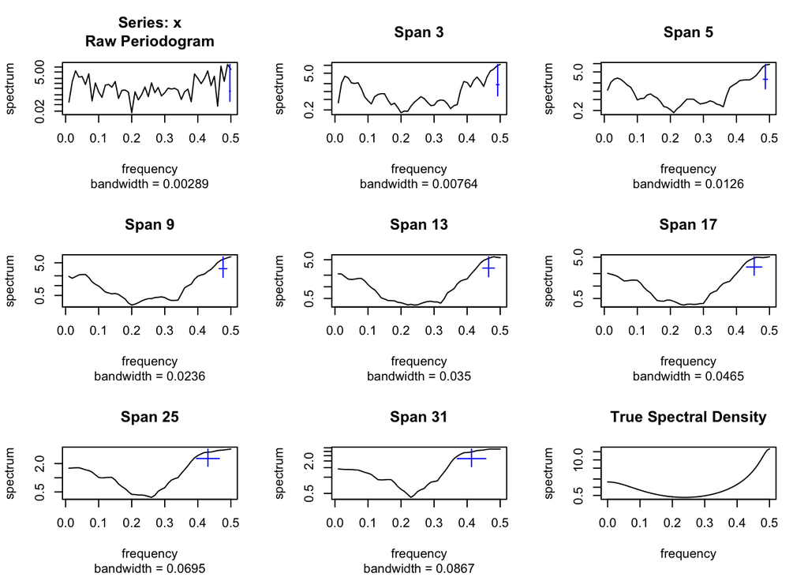

```r
set.seed(746)
x = arima.sim(n=100, model=list(ar=c(-0.3, 0.5)))

spans = c(3, 5, 9, 13, 17, 25, 31)

par(mfrow = c(3,3))
spec.pgram(x)
for(k in spans){
spec.pgram(x, spans=k, main=paste0('Span ', k))
}
arma.spec(ar=c(-0.3, 0.5), main = 'True Spectral Density')
```